# Descriptive Statistics Review

# Overview

This notebook will provide an overview of basic statistics. This is not meant to replace the full-semester course that you should have already taken, but rather to demonstrate how to implement the techniques learned in that class using R.

Before we get started, a brief note on graphing. We will be using both Base R graphics and `ggplot()` graphics. In my opinion, `ggplot()` makes better looking graphics and is more intuitive when you want to customize your graphs than Base R. But sometimes, you just want a quick and dirty graph, and Base R is just fine for that. This notebook will use both from time to time; for your assignments, focus on using `ggplot()`. Also, I won’t be wasting a lot of time making every graph look “good” here. A good looking graph needs to have a title, axis titles, legends, and so forth. For the purposes of this set of notes, sometimes I will put in the effort to make the graph look proper when it is a `ggplot()` graph, sometimes I won’t. A deeper dive into data visualization is well beyond the scope of this course.

Finally, before we get going, let’s load in the packages we will be needing and load and attach 2 data sets:

```r
library(tidyverse)
library(stargazer)
library(AER)
data(CPS1985)
data(vote1)
attach(vote1)
```

# The Grammar of Graphics

The `ggplot()` function is in the `ggplot2` package, which is part of the `tidyverse`. It is based on a graphing philosophy called the **Grammar of Graphics**. The Grammar of Graphics is based on the idea that a graphic has a set of indispensable elements:

- **Aesthetic** - The dimensions and visual attributes of the graph. This can be the x/y dimension, but also you can graph using color, size, and so forth
- **Layers** - Objects are created on the aesthetic in layers. Each layer includes, or is defined by:
  - **Data** - what is being graphed
  - **Mapping** - how the data is put into the layer
  - **Statistical Transformation** - how are you displaying the data? raw data? means? counts?
  - **Geometry** - the physical display of the data (bars, points, lines, area)
  - **Position** - placement of graphic elements for clarity of understanding

These are some higher level data visualization ideas that is beyond the scope of this class. Still, understanding a bit of this is helpful to making good graphics with `ggplot()`.

# Basic Graphing Techniques

## Bar and Pie Charts

Let’s start with bar charts and pie charts. For basic bar charts, I find `ggplot()` much easier than base R. Here is a bar chart of the CPS data by occupation:

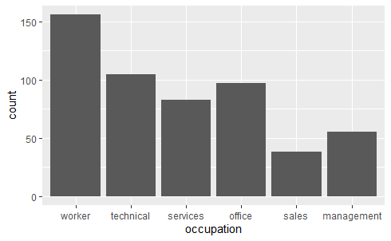

```r
CPS1985 %>% ggplot(aes(x = occupation))+
    geom_bar()
```

How does this code work?

- `CPS1985 %>%` pipes the CPS data into the `ggplot()` function
- `aes()` is where I set the *aesthetic* for the graph. I want the x dimension to be the occupation variable, hence `aes(x = occupation)`. I don’t need to define y because I’m making a bar graph
- Adding the `+` allows me to break up my code over multiple lines. This is optional but makes for much neater looking R scripts when making fancy graphs.
- `geom_bar()` creates a basic bar chart. The *geometry* is that of a *bar chart*.

This can be made to look more proper very quickly:

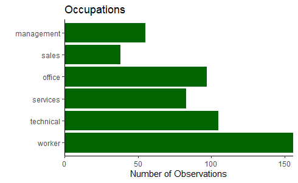

```r
CPS1985 %>% ggplot(aes(x = occupation))+
    geom_bar(fill = "dark green") +
    coord_flip() +
    scale_y_continuous(expand = c(0,0)) +
    theme_classic() +
    labs(title = "Occupations", x = "", y = "Number of Observations")
```

```r
NA
```

Bar charts in Base R require more work. First, you need to create an object with the relevant counts by utilizing the `table()` command:

```r
jobtype <- table(occupation)
jobtype
```

```
occupation
    worker  technical   services     office      sales management
       156        105         83         97         38         55
```

This transformed the data into a table of counts. Now, we can graph this object with the `barplot()` function.

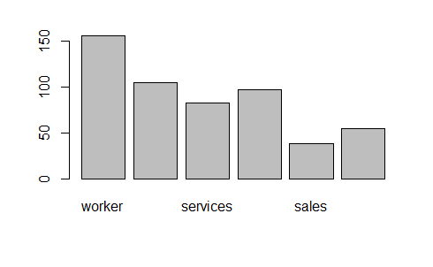

```r
barplot(jobtype)
```

This plot is also customizable in many of the say ways the `ggplot()` one was if you want to look into it.

We can also display this sort of data in a pie chart. Fun fact: most people who study data visualization believe that a pie chart is a really awful way to graph data. This may be why `ggplot2` doesn’t have an easy way of making a pie chart–they know better! However, you can make a pie chart in base R very easily with:

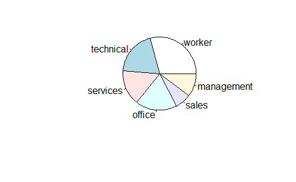

```r
pie(jobtype)
```

I am on team “Pie Charts are Evil”. Why are they evil? Let’s write some simple code to simulate the rolling of 100 dice so we can create a frequency distribution of the dice rolls.

```r
set.seed(8675309)
a <- sample(1:6, 100, replace = TRUE)
b <- table(a)
b
```

```
a
 1  2  3  4  5  6
18  8 20 16 17 21
```

Now, let’s see whether or not the pie chart or the bar chart makes it more clear which outcome occurred the most often:

First the pie chart:

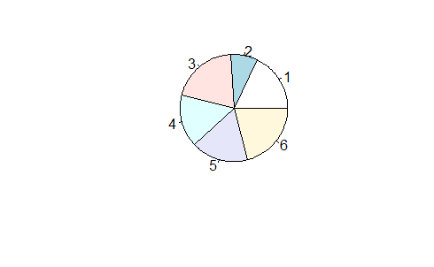

```r
pie(b)
```

Can you tell the difference between 3 and 6? How about between 1, 4, and 5?

The differences are much plainer to see in a bar chart:

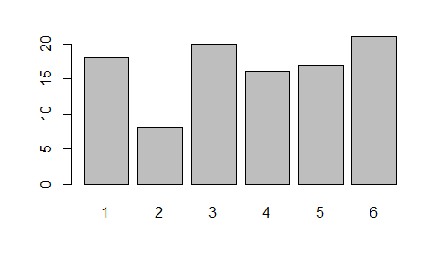

```r
barplot(b)
```

### Data for further exploration

Analyze the hiphop lyrics dataset *and* one of the other two datasets below using bar charts created with `ggplot()`. Ensure that your bar charts include x- and y- axis labels and a title.

- Look at `fivethirtyeight:hiphop_cand_lyrics` and make bar charts of $sentiment$ for both Donald Trump and Hillary Clinton.
- Examine the Use the `AER:BankWages` data to see which job type ($job$) is the most common in the data set.
- Create a bar chart looking at the distribution of student $ethnicity$ in the `AER:STAR` data.

## Boxplots

A **boxplot** (sometimes called a **Box and Whiskers Plot**) are a very common way of displaying the distribution of numerical data by showing the 0th, 25th, 50th, 75th, and 100th quartile of data on a graph. I usually skip them when I teach intro to stats because they are stupidly hard to make in Excel. But they are a snap in R. Here is a `boxplot()` of the wage data in base R:

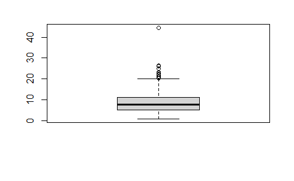

```r
boxplot(wage)
```

And now for `ggplot()`

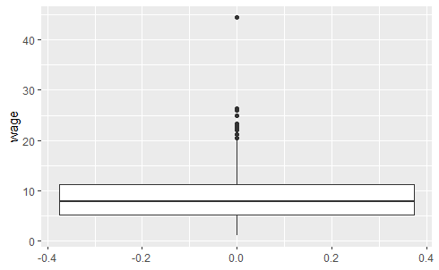

```r
CPS1985 %>% ggplot(aes(y = wage)) +
    geom_boxplot()
```

This can be made to look a little more standard with another argument

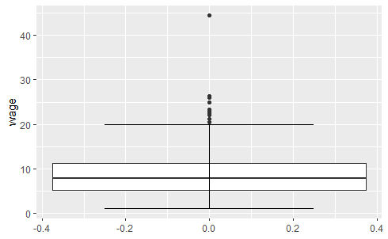

```r
CPS1985 %>% ggplot(aes(y = wage)) +
    geom_boxplot() +
    stat_boxplot(geom = "errorbar", width = 0.5)
```

Boxplots are more powerful when looking at distributions across groups. Let’s see what the distribution of income looks like for each of the 6 employment types. First in base R:

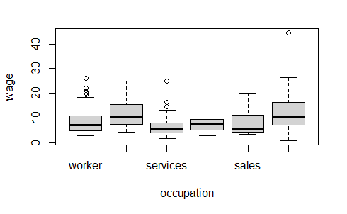

```r
boxplot(wage ~ occupation)
```

We will use the (`~`) frequently in r, it basically means “as a function of” so we are making boxplots of wage *as a function of* occupation.

This seems to be missing the label for management class, and we’d have to do some work to put it in there. But I’d do this in `ggplot()` anyway, so:

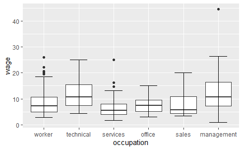

```r
CPS1985 %>% ggplot(aes(x = occupation, y = wage)) +
    geom_boxplot() +
    stat_boxplot(geom = "errorbar", width = 0.5)
```

```r
NA
```

The aesthetic of `aes(x = occupation, y = wage)` tells the `ggplot()` that We are plotting wage on the y (vertical) axis and occupation on the x (horizontal) axis.  
We can get more complicated with our boxplots. Let’s say we want to look at gender differences in the distribution of wage.

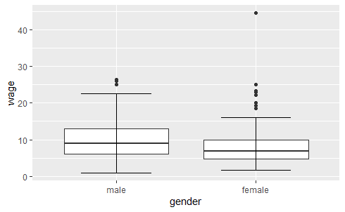

```r
CPS1985 %>% ggplot(aes(x = gender, y = wage)) +
    geom_boxplot() +
    stat_boxplot(geom = "errorbar", width = 0.5)
```

Men seem to make more. Maybe your theory is that this gender wage gap is driven by marital status, so now we have 2 factor variables. We can include one of these factors as a fill aesthetic:

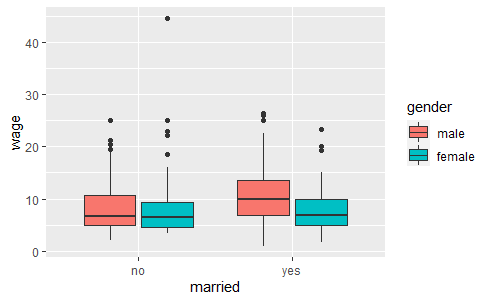

```r
CPS1985 %>% ggplot(aes(x = married, y = wage, fill = gender)) +
    geom_boxplot()
```

What happens if we put married as our fill variable and gender as our x variable?

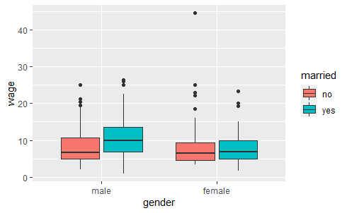

```r
CPS1985 %>% ggplot(aes(x = gender, y = wage, fill = married)) +
    geom_boxplot()
```

Same data, same boxes, but the arrangement of the boxes tells a different story.

As usual, ggplot2 graphs clean up quite nicely if you invest the time to learn the features.

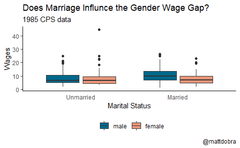

```r
CPS1985 %>% ggplot(aes(x = married, y = wage, fill = gender)) +
    geom_boxplot() +
    theme_classic() +
    labs(title = "Does Marriage Influnce the Gender Wage Gap?",
         subtitle = "1985 CPS data",
         x = "Marital Status",
         y = "Wages",
         fill = "",
         caption = "@mattdobra") +
    scale_fill_manual(values= c("deepskyblue4", "darksalmon")) +
    theme(legend.position = "bottom",
          legend.direction = "horizontal",
          axis.ticks.x = element_blank()) +
    scale_x_discrete(labels = c("no" = "Unmarried", "yes" = "Married"))
```

## Histograms

Histograms are useful for displaying the distribution of continuous data. Again, these are much easier to do in R than in something like Excel. Here is the distribution of respondent age in the CPS1985 data set using the `hist()` function.

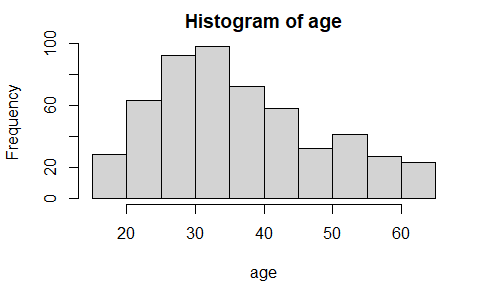

```r
hist(age)
```

And again with `ggplot()`:

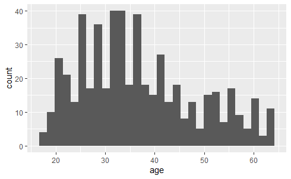

```r
CPS1985 %>%  ggplot(aes(x = age)) +
    geom_histogram()
```

Base R usually does a good job picking the right bin width for histograms, but `ggplot()` nearly always chooses 30 for some reason. This is easy to sort out in `ggplot()`. We can also add the outlines for the bars easily.

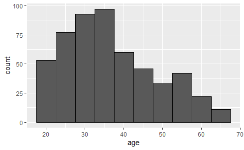

```r
CPS1985 %>%  ggplot(aes(x = age)) +
    geom_histogram(binwidth = 5, color = "black")
```

Note that with `ggplot()`, usually the `color` option is used for outlines and `fill` is used to color in spaces. Let’s make our graph with the MU official colors, obtained from the 2020 *Methodist University Identity Standards Manual*: * MU Green (#00573C) * Metallic Gold (#B4985A) * Non-Metallic Gold (#CBB676)

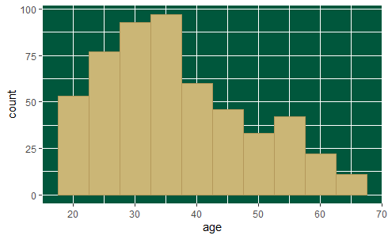

```r
CPS1985 %>%  ggplot(aes(x = age)) +
    geom_histogram(binwidth = 5, fill = "#CBB676", color = "#B4985A") +
    theme(panel.background = element_rect(fill = ("#00573C")))
```

Not a fan. Maybe this:

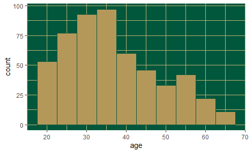

```r
CPS1985 %>%  ggplot(aes(x = age)) +
    geom_histogram(binwidth = 5, fill = "#B4985A", color = "#00573C") +
    theme(
        panel.background = element_rect(fill = "#00573C"),
        panel.grid.major = element_line(color = "#CBB676"),
        panel.grid.minor = element_line(color = "#CBB676"))
```

Ok, enough silliness.

### Data for further exploration

Choose one of the data sets below to practice creating boxplots and histograms using `ggplot()`. Again, ensure you have well labeled plots, including titles and appropriate labels.

- Using the `AER:NMES1988` dataset, create a histogram of the number of physician office visits ($visits$) and a box plot looking at the number of $visits$ by $health$ status.
- Using the `dplyr:starwars` dataset, create a histogram of the $height$ of Star Wars characters and a box plot looking at height by the $sex$ of the characters.

## Stacked and grouped bar charts

These are used to look at the compositions of groups. This is another place where `ggplot()` is a bit easier. TO make a stacked or grouped bar chart in Base R, we start by making a table. Let’s look at the gender composition of each occupation.

```r
table1 <- table(gender, occupation)
table1
```

```
        occupation
gender   worker technical services office sales management
  male      126        53       34     21    21         34
  female     30        52       49     76    17         21
```

Now we can create a stacked `barplot()`

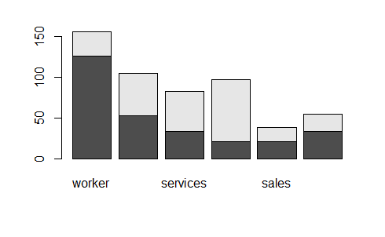

```r
barplot(table1)
```

or a side-by-side `barplot()` by specifying `beside = TRUE`:

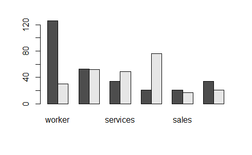

```r
barplot(table1, beside = TRUE)
```

Next, using `ggplot()`:

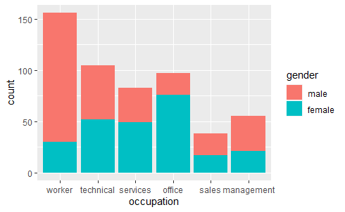

```r
CPS1985 %>% ggplot(aes(x = occupation, fill = gender)) +
    geom_bar()
```

Let’s edit the colors. Gender stereotype colors probably enhance readability to the viewer, but if you want to avoid them, then you probably don’t want to do the exact opposite of what people expect.

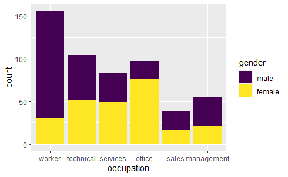

```r
CPS1985 %>% ggplot(aes(x = occupation, fill = gender)) +
    geom_bar() +
    scale_fill_viridis_d()
```

This is easily modified to a side-by-side chart with the option `position = "dodge"` in the `geom_bar()` layer

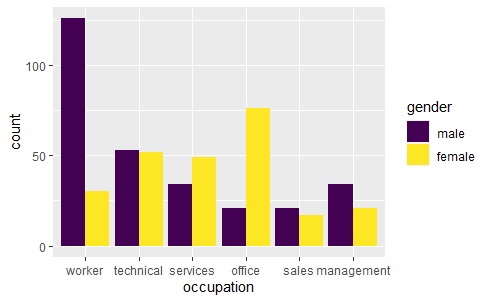

```r
CPS1985 %>% ggplot(aes(x = occupation, fill = gender)) +
    geom_bar(position = "dodge") +
    scale_fill_viridis_d()
```

One use of the stacked bar chart is to show proportions. We can accomplish this by using the `position = "fill` option in our `geom_bar()` layer.

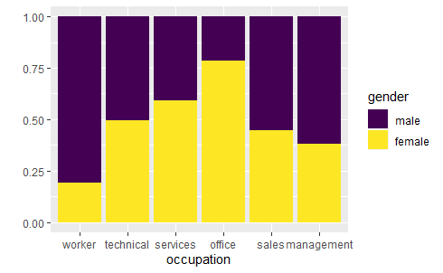

```r
CPS1985 %>% ggplot(aes(x = occupation, fill = gender)) +
    geom_bar(position = "fill") +
    scale_fill_viridis_d() +
    labs(y = "")
```

This iteration shows the relative proportions pretty well.

## Scatter Plots

Scatter plots are useful for looking at the relationship between 2 numerical (preferably continuous) variables. Because there is only 1 continuous variable in the CPS1985 dataset, let’s switch to using the vote1 dataset. To see what is in this, type `?vote1` in your console. We might also want to get a quick overview of the data with the `head(vote1)` command:

```r
head(vote1)
```

|  | state | district | democA | voteA | expendA | expendB | prtystrA | lexpendA | lexpendB | shareA |
| --- | --- | --- | --- | --- | --- | --- | --- | --- | --- | --- |
| 1 | AL | 7 | 1 | 68 | 328.296 | 8.737 | 41 | 5.793916 | 2.167567 | 97.40767 |
| 2 | AK | 1 | 0 | 62 | 626.377 | 402.477 | 60 | 6.439952 | 5.997638 | 60.88104 |
| 3 | AZ | 2 | 1 | 73 | 99.607 | 3.065 | 55 | 4.601233 | 1.120048 | 97.01476 |
| 4 | AZ | 3 | 0 | 69 | 319.690 | 26.281 | 64 | 5.767352 | 3.268846 | 92.40370 |
| 5 | AR | 3 | 0 | 75 | 159.221 | 60.054 | 66 | 5.070293 | 4.095244 | 72.61247 |
| 6 | AR | 4 | 1 | 69 | 570.155 | 21.393 | 46 | 6.345908 | 3.063064 | 96.38355 |

Let’s look at the relationship between the share of campaign expenditures (shareA) and vote share received (voteA). Base R makes a simple scatter plot with the plot function. The syntax is `plot(y ~ x)`; recall, think of the `~` as saying “as a function of” here.

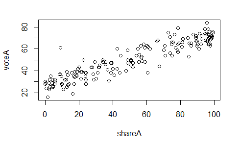

```r
plot(voteA ~ shareA)
```

Why `plot(voteA ~ shareA)` and not `plot(shareA ~ voteA)`? In this case, theory tells that vote share should be the **dependent variable** and campaign expenditures should be the **independent variable**, and when graphing the generally accepted norm is to put the DV (dependent variable) on the Y axis.

In `ggplot()`, this looks like:

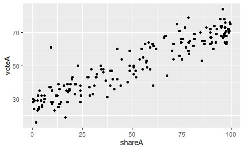

```r
vote1 %>% ggplot(aes(x = shareA, y = voteA)) +
    geom_point()
```

Perhaps you want to see the line of best fit? We can add the following argument to our `ggplot()`:

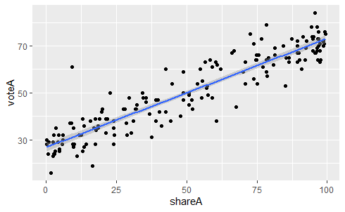

```r
vote1 %>% ggplot(aes(x = shareA, y = voteA)) +
    geom_point() +
    geom_smooth(method = lm)
```

As before, we can add elements if we want here. For example, maybe we want to highlight the parties

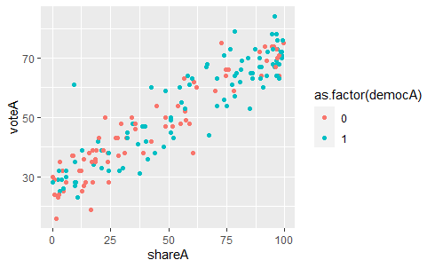

```r
vote1 %>% ggplot(aes(x = shareA, y = voteA, color = as.factor(democA))) +
    geom_point()
```

Or perhaps separate graphs for the Democrats and Republicans, and going back to MU colors because why the hell not:

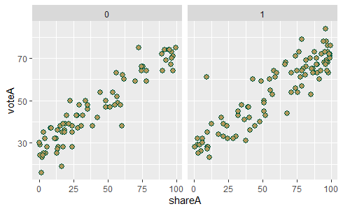

```r
vote1 %>% ggplot(aes(x = shareA, y = voteA)) +
    geom_point(color = "#00573C", fill = "#B4985A", shape = 21, size = 2.5) +
    facet_wrap(~democA)
```

All in all, R has some extremely powerful graphing capabilities that go well beyond what something like Excel is capable of. It’s no surprise that many major news networks use R, and particularly `ggplot()` to do their graphics. For example, the BBC and the New York Times produce many of their graphics using `ggplot()`, as does The Economist. In fact, the BBC has even distributed a package you can download called `bbplot` that you can install (using `devtools` unfortuantely) make your graphs look like BBC graphics!

### Data for further exploration

Choose two of the data sets below to practice creating scatterplots using `ggplot()`. Again, ensure you have well labeled plots, including titles and appropriate labels.

- Use `datasets:USArrests` to look at the relationship between urbanization ($UrbanPop$) and each of the three measures of crime.
- Look at the relationship between alcohol consumption ($alcohol$) and $deaths$, $heart$, and $liver$ in `wine:wooldridge`.
- Using `wooldridge:meap01`, look at the relationship between expenditures per student ($expp$) and the various test scores ($math4$ and $read4$).

# Summarizing Data Numerically

Now that we have seen an overview of the graphical capabilities, let’s turn to numerical summaries. We return to the CPS1985 dataset so we can look at both numerical and categorical variables.

## Categorical Variables

Let’s start with categorical variables and focus on occupation. Categorical variables are summarized with frequencies or proportions. The `table` command works to create these.

```r
table(occupation)
```

```
occupation
    worker  technical   services     office      sales management
       156        105         83         97         38         55
```

These are counts. The easiest way to convert this to proportions is to divide your totals by the size of the data set. Here are a few ways to get there:

```r
table(occupation)/534
```

```
occupation
    worker  technical   services     office      sales management
0.29213483 0.19662921 0.15543071 0.18164794 0.07116105 0.10299625
```

You can also produce contingency (two-way) tables that look at the intersection of two categorical variables:

```r
table(occupation, gender)
```

```
            gender
occupation   male female
  worker      126     30
  technical    53     52
  services     34     49
  office       21     76
  sales        21     17
  management   34     21
```

## Numerical Variables

While we are limited in how we describe categorical variables, we have lots of options with respect to numerical variables. Let’s analyze the wage variable.

Arithmetic means are calculated with the `mean()` function.

```r
mean(wage)
```

```
[1] 9.024064
```

A trimmed mean drops the outliers from the top and bottom of the data. For example, if we type:

```r
mean(wage, trim = 0.05)
```

```
[1] 8.544212
```

We tell R to drop the 5% of the lowest wages and 5% of the highest wages from the data and calculate the mean of the middle 90%. Sometimes this makes sense when you are looking at a data set with a low of skew. Another thing we might do get a measure of central tendency for skewed data is to calculate a `median()`.

```r
median(wage)
```

```
[1] 7.78
```

Variance and Standard Deviation are calculated with `var()` and `sd()`, respectively.

```r
var(wage)
```

```
[1] 26.41032
```

```r
sd(wage)
```

```
[1] 5.139097
```

Don’t forget, the standard deviation is the square root of the variance!

```r
sd(wage)^2
```

```
[1] 26.41032
```

```r
sqrt(var(wage))
```

```
[1] 5.139097
```

Minima and maxima can be calculated with the `min()` and `max()` commands

```r
min(wage)
```

```
[1] 1
```

```r
max(wage)
```

```
[1] 44.5
```

You can get both easily if you want using `range()`

```r
range(wage)
```

```
[1]  1.0 44.5
```

Measures of position (quartiles, percentiles, etc) can be obtained through the `quantile()` function. You need to pass through a `probs` argument to tell it which quantile you want.

If you just one one specific quantile–in this case the first quartile–you type:

```r
quantile(wage, .25)
```

```
 25%
5.25
```

You can also use the `c()` language we’ve seen before to get multiple quantiles at once. For example, if we want the 10th, 25th, 50th, 75th, nd 90th percentile, we type:

```r
quantile(wage, probs = c(.1, .25, .5, .75, .9))
```

```
   10%    25%    50%    75%    90%
 4.000  5.250  7.780 11.250 15.275
```

The minimum and maximum of the data can also be obtained using the 0th and 100th quartile:

```r
quantile(wage, probs = c(0,1))
```

```
  0% 100%
 1.0 44.5
```

Correlation coefficients can be calculated using `cor()`. Here is the correlation between education and wage:

```r
cor(wage, education)
```

```
[1] 0.3819221
```

This indicates a moderate positive correlation between the two variables. We can see this correlation in this graph:

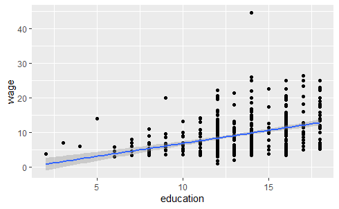

```r
CPS1985 %>% ggplot(aes(x = education, y = wage)) +
    geom_point() +
    geom_smooth(method = lm)
```

By default, R calculates the Pearson correlation, which is appropriate for interval data, sometimes you have ordinal data where a Spearman correlation makes more sense, for example, when the data is a ranking but not a measure. In this case, the Pearson is quantifing the linear relationship between education and wage, but a Spearman test simply asks whether or not higher levels of education are linked to higher wages.

```r
cor(wage, education, method = "spearman")
```

```
[1] 0.3813425
```

In most economic applications, Pearson is more useful.

Don’t forget, the `summary()` command can be useful here too:

```r
summary(wage)
```

```
   Min. 1st Qu.  Median    Mean 3rd Qu.    Max.
  1.000   5.250   7.780   9.024  11.250  44.500
```

The `stargazer()` package/function makes nicely formatted tables of summary statistics, but you have to put in a whole dataframe:

```r
stargazer(CPS1985, type = "text")
```

```
=============================================================
Statistic   N   Mean  St. Dev.  Min  Pctl(25) Pctl(75)  Max
-------------------------------------------------------------
wage       534 9.024   5.139   1.000  5.250    11.250  44.500
education  534 13.019  2.615     2      12       15      18
experience 534 17.822  12.380    0      8        26      55
age        534 36.833  11.727   18      28       44      64
-------------------------------------------------------------
```

```r
stargazer(CPS1985, type = "html")
```

| Statistic | N | Mean | St. Dev. | Min | Pctl(25) | Pctl(75) | Max |
| --- | --- | --- | --- | --- | --- | --- | --- |
| wage | 534 | 9.024 | 5.139 | 1.000 | 5.250 | 11.250 | 44.500 |
| education | 534 | 13.019 | 2.615 | 2 | 12 | 15 | 18 |
| experience | 534 | 17.822 | 12.380 | 0 | 8 | 26 | 55 |
| age | 534 | 36.833 | 11.727 | 18 | 28 | 44 | 64 |

# Wrapping Up

This notebook reviewed the first half of an intro to statistics class using R. The next step is to tackle inferential statistics using R.